# Solutions to Estimation Exercises

January 2020

## Exercise 1 (optional)

This exercise is for those wishing to understand stratified estimation a bit better. It is to be calculated by hand (or using R, a spreadsheet or a calculator). Note: You might have to round up or down. Consider this (very small) population:

[figure not shown]

Each stratum has 12 units, i.e. \(N = 48, N_1 = N_2 = N_3 = N_4 = 12\)

And we have that:

\(n_1 = 6\), \(n_2 = 4\), \(n_3 = 3\), \(n_2 = 2\),

The units drawn satisfy (for ease of computation):

\(y_1 = y_{1_1} =y_{1_2} = y_{1_3} = y_{1_4} = y_{1_5}=y_{1_6} = 4\), \(y_2 = y_{2_1} =y_{2_2} = y_{2_3} = y_{2_4} = 6\),  
\(y_3 = y_{3_1} =y_{3_2} = y_{3_3} = 8\),  
\(y_4 = y_{4_1} =y_{4_2} = 12\).

Calculate an estimate of the population total \(\hat{t}_y = \sum_{i = 1}^4 \sum_{j=1}^{n_i} d_i y_{i_j}\)

We have that:

\(d_1 = \frac{N_1}{n_1} = \frac{12}{6} = 2\), \(d_2 = \frac{N_2}{n_2} = \frac{12}{4} = 3\),

\(d_3 = \frac{N_3}{n_3} = \frac{12}{3} = 4\), \(d_4 = \frac{N_4}{n_4} = \frac{12}{2} = 6\),

Thus,

\(\hat{t}_y = \sum_{i = 1}^4 \sum_{j=1}^{n_i} d_i y_{i_j} =\)

\(\sum_{j=1}^6 2 \cdot 4 + \sum_{k=1}^4 3\cdot 6 + \sum_{l = 1}^3 4 \cdot 8 + \sum_{m=1}^2 6 \cdot 12 =\)

\((6 \cdot 2 \cdot 4) + (4 \cdot 3 \cdot 6) + (3 \cdot 4 \cdot 8) + (2 \cdot 6 \cdot 12) = 360\)

## Exercise 2

Use the dataset **mydata_estimation**.

Given your proportional sample from last session, calculate a direct and a calibrated estimate of the number of emnployees in 2020. Use Nr_empl_reg for calibration.

Dont’ forget to check your \(g_i\)’s.

What is the ratio of the standard error of the proportional estimator to the standard error of the calibrated estimator?

**Solution to exercise 2**

First, load package survey and your data:

```r
library(survey)
```

```r
load(file="mydata_estimation.Rda")

load(file="mysampprop.Rda")

load(file="mysamopt.Rda")
```

Make them into survey objects:

```r
mysampprop$dwgt <- 1/mysampprop$Prob


srs.design.prop <- svydesign(ids=~1,
                        strata=~stratum,
                        weights=~dwgt,
                        fpc = ~Prob,
                        data=mysampprop)


mysampopt$dwgt <- 1/mysampopt$Prob


srs.design.opt <- svydesign(ids=~1,
                        strata=~stratum,
                        weights=~dwgt,
                        fpc = ~Prob,
                        data=mysampopt)
```

Direct estimate:

```r
(emp20.hat <- svytotal(~Nr_empl_2020, srs.design.prop))
```

```
##                total    SE
## Nr_empl_2020 2605997 43373
```

Calibrated estimate:

```r
(cgoal <- c('(Intercept)'=nrow(mydata_estimation), 'Nr_empl_reg'=sum(mydata_estimation$Nr_empl_reg)))
```

```
## (Intercept) Nr_empl_reg
##       10000     2627857
```

```r
cal.svyobj <- calibrate (srs.design.prop,
                         formula=~Nr_empl_reg,
                         population=cgoal)

(empl20.cal <- svytotal (~Nr_empl_2020, cal.svyobj))
```

```
##                total    SE
## Nr_empl_2020 2619382 12389
```

```r
mysampprop$cw <- weights(cal.svyobj)

mysampprop$gw <- mysampprop$cw / mysampprop$dw
```

Check your \(g_i\)’s (they look OK):

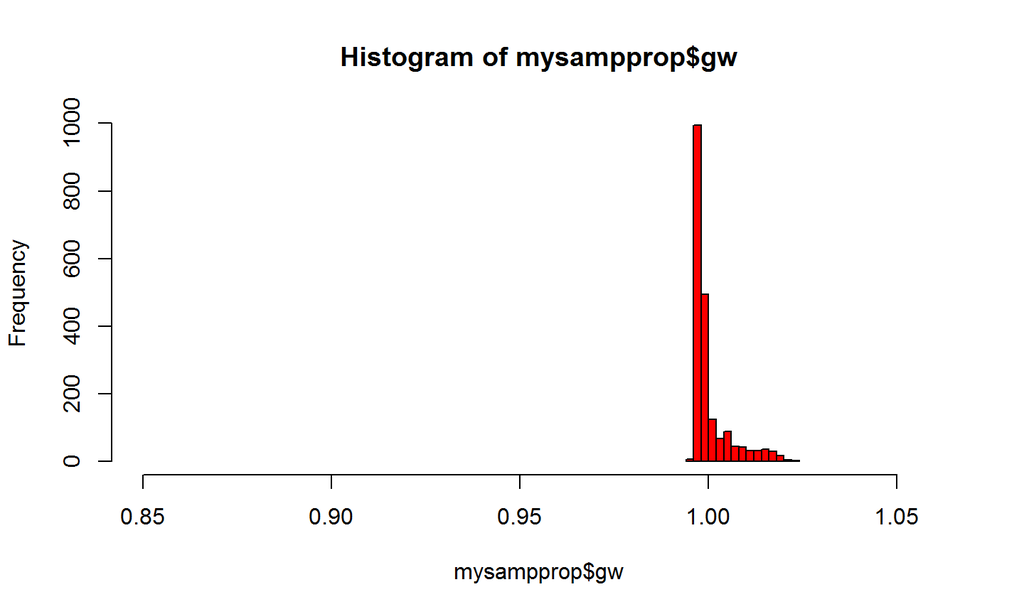

```r
hist(mysampprop$gw, col = "red", xlim =c(0.85, 1.06))
```

The ratio is

```r
SE(emp20.hat)/SE(empl20.cal)
```

```
##              Nr_empl_2020
## Nr_empl_2020     3.500841
```

Repeat exercise 2 for the optimal sample.

In which case do you gain most from calibrating (i.e. in which case - proportional or optimal - do you have the largest ratio)?

**Solution to ecercise 3**

We already made a survey object, so all we have to do is:

Direct estimate:

```r
(emp20.opt <- svytotal(~Nr_empl_2020, srs.design.opt))
```

```
##                total    SE
## Nr_empl_2020 2617548 12816
```

Calibrated estimate:

```r
(cgoal <- c('(Intercept)'=nrow(mydata_estimation),
            'Nr_empl_reg'=sum(mydata_estimation$Nr_empl_reg)))
```

```
## (Intercept) Nr_empl_reg
##       10000     2627857
```

```r
cal.svyobj.opt <- calibrate (srs.design.opt,
                         formula=~Nr_empl_reg,
                         population=cgoal)

(empl20.cal.opt <- svytotal (~Nr_empl_2020, cal.svyobj.opt))
```

```
##                total     SE
## Nr_empl_2020 2618897 6968.6
```

```r
mysampopt$cw <- weights(cal.svyobj.opt)

mysampopt$gw <- mysampopt$cw / mysampopt$dw
```

Check your \(g_i\)’s (they look OK):

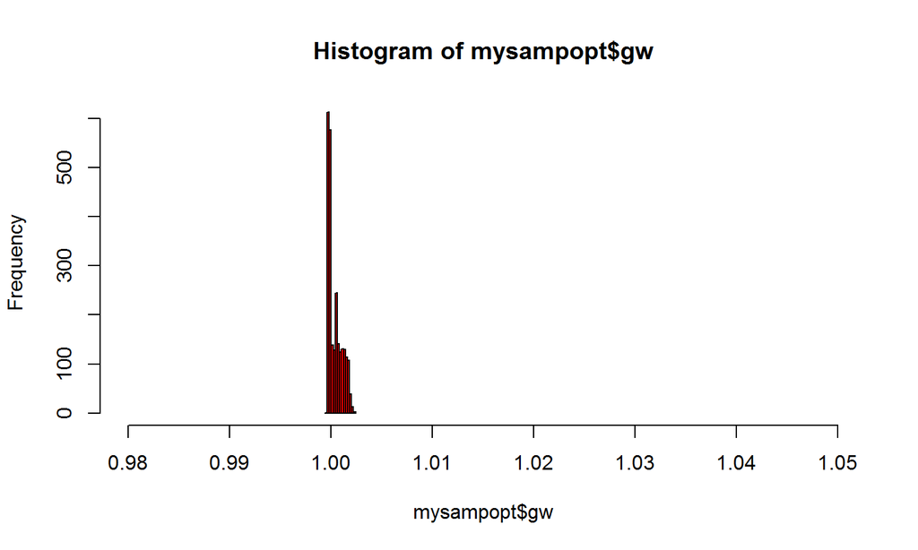

```r
hist(mysampopt$gw, col = "red", xlim =c(0.98, 1.05))
```

The ratio is

```r
SE(emp20.opt)/SE(empl20.cal.opt)
```

```
##              Nr_empl_2020
## Nr_empl_2020     1.839129
```

## Exercise 4

Calculate the means of Nr_empl_reg (corresponding to number of employees in 2019), Nr_empl_2020, turnover_2019 and turnover_2020.

**Hint: The function svymean(~x, my_syvobject) will give you the mean of variable x from the survey object my_svyobject)**

Which mean has changed most percentage-wise from 2019 to 2020?

**Solution to ecercise 4**

First the means:

```r
(empl19_m <- svymean(~Nr_empl_reg, srs.design.opt))
```

```
##               mean     SE
## Nr_empl_reg 262.64 1.2985
```

```r
(empl20_m <- svymean(~Nr_empl_2020, srs.design.opt))
```

```
##                mean     SE
## Nr_empl_2020 261.75 1.2816
```

```r
(to19_m <- svymean(~turnover_2019, srs.design.opt))
```

```
##                  mean     SE
## turnover_2019 1312889 6988.4
```

```r
(to20_m <- svymean(~turnover_2020, srs.design.opt))
```

```
##                  mean     SE
## turnover_2020 1312616 7087.7
```

Then the changes:

```r
(perc_empl <- abs(1 - empl19_m[1]/empl20_m[1])*100)
```

```
## Nr_empl_reg
##   0.3392753
```

```r
(perc_to <- abs(1 - to19_m[1]/to20_m[1])*100)
```

```
## turnover_2019
##    0.02081124
```

The average number of employees has changed more then the average turnover percentage-wise.